# Datos históricos de flota de taxis en Madrid

Alejandro Vaqueiro, Ester Sánchez, Inês Bolaños, Silvia Lendínez

15 febrero 2019

Debido a la falta de datos, queremos resaltar que para este trabajo no vamos a utilizar el tema de nuestro TFM.

Hemos utilizado una base de datos sobre la flota de taxis dentro de la ciudad de Madrid. Vamos a usar información como las marcas, el combustible y la cilindrada y potencia de los vehiculos para realizar un análisis exploratorio, teniendo en cuenta las limitaciones del tipo de variables a la hora de hacer gráficos.

El objetivo de nuestro trabajo es aprender a limpiar una base de datos, transformar, visualizar e interpretar las principales variables.

Para ello, en primer lugar, hemos importado el archivo *TaxiFlota.csv.* Luego, hemos realizado la limpieza de datos (cambio de variables, cambiar el nombre de las columnas, eliminar columnas, formato fecha, etc.)

Por último hemos hecho algunas representaciones gráficas con las variables más relevantes.

# 1. Obtención de los datos

Importación de la base de datos *Taxi Flota* de la base de datos abiertos de Madrid, en formato .csv

```r
datos <- read.table("TaxiFlota.csv", sep = ";", header = TRUE, stringsAsFactors = FALSE )
```

Vemos la dimensión

```r
dim(datos)
```

```
## [1] 46942    18
```

Mostramos la info de las 5 primeras filas

```r
head(datos,5)
```

```
##    Código Matrícula Fecha.Matriculación Marca  Modelo Tipo Variante
## 1 1020144   2239DTJ          13/12/2005 SKODA OCTAVIA
## 2  550040   8901GJP          21/11/2008 SKODA OCTAVIA
## 3  550016   6364FVW          14/12/2007  SEAT  TOLEDO
## 4  550115   4249GST          08/01/2010 SKODA OCTAVIA
## 5  550142   1561GVY          27/04/2010 SKODA OCTAVIA
##   Clasificación.medioambiental Combustible Cilindrada Potencia
## 1                                   DIESEL          0       12
## 2                                   DIESEL          0       12
## 3                                   DIESEL          0       12
## 4                                   DIESEL          0       12
## 5                                   DIESEL          0       12
##   Número.de.Plazas Fecha.inicio.de.prestación.del.servicio.de.taxi
## 1                                                       16/12/2005
## 2                                                       11/12/2008
## 3                                                       18/11/2008
## 4                                                       14/01/2010
## 5                                                       01/03/2010
##   Eurotaxi Régimen.Especial.de.Eurotaxi
## 1       NO                           NO
## 2       NO                           NO
## 3       NO                           NO
## 4       NO                           NO
## 5       NO                           NO
##   Fecha.inicio.Régimen.Especial.Eurotaxi
## 1
## 2
## 3
## 4
## 5
##   Fecha.fin.Régimen.Especial.Eurotaxi      Fecha
## 1                                     30/07/2018
## 2                                     30/07/2018
## 3                                     30/07/2018
## 4                                     30/07/2018
## 5                                     30/07/2018
```

Mostramos los últimos datos

```r
tail(datos)
```

```
##        Código Matrícula Fecha.Matriculación      Marca Modelo Tipo
## 46937 1483887   1747KDP          11/10/2017 VOLKSWAGEN  CADDY   2K
## 46938 1303136   9672HST          12/09/2013 VOLKSWAGEN   GOLF  1KM
## 46939 1384128   9059JFJ          11/05/2015 VOLKSWAGEN  CADDY   2K
## 46940 1334201   5327HWF          18/03/2014 VOLKSWAGEN   GOLF  1KM
## 46941 1385365   3742JGG          18/06/2015 VOLKSWAGEN  CADDY   2K
## 46942 1329779   3975HVK          24/01/2014 VOLKSWAGEN   GOLF  1KM
##                         Variante Clasificación.medioambiental Combustible
## 46937                   AFDFSB??                            C      DIESEL
## 46938 ACCAYCX0/FM5********N*****                            B      DIESEL
## 46939                  ACCAYDX01                            B      DIESEL
## 46940 ACCAYCX0/FM5********N*****                            B      DIESEL
## 46941                  AFCAYDX01                            B      DIESEL
## 46942 ACCAYCX0/FM5********N*****                            B      DIESEL
##       Cilindrada Potencia Número.de.Plazas
```

[output cut: 27 more lines]

# 2. Tratamiento y limpieza

## 1. Renombrar los nombres de las columnas

### 1.1 Cambiar los títulos a minúsculas

```r
colnames(datos) <- sapply(colnames(datos), tolower)
colnames(datos)
```

```
##  [1] "código"
##  [2] "matrícula"
##  [3] "fecha.matriculación"
##  [4] "marca"
##  [5] "modelo"
##  [6] "tipo"
##  [7] "variante"
##  [8] "clasificación.medioambiental"
##  [9] "combustible"
## [10] "cilindrada"
## [11] "potencia"
## [12] "número.de.plazas"
## [13] "fecha.inicio.de.prestación.del.servicio.de.taxi"
## [14] "eurotaxi"
## [15] "régimen.especial.de.eurotaxi"
## [16] "fecha.inicio.régimen.especial.eurotaxi"
## [17] "fecha.fin.régimen.especial.eurotaxi"
## [18] "fecha"
```

### 1.2 Sustituir los espacios por “_"

```r
colnames(datos) <- gsub("\\.", "_", colnames(datos))
colnames(datos)
```

```
##  [1] "código"
##  [2] "matrícula"
##  [3] "fecha_matriculación"
##  [4] "marca"
##  [5] "modelo"
##  [6] "tipo"
##  [7] "variante"
##  [8] "clasificación_medioambiental"
##  [9] "combustible"
## [10] "cilindrada"
## [11] "potencia"
## [12] "número_de_plazas"
## [13] "fecha_inicio_de_prestación_del_servicio_de_taxi"
## [14] "eurotaxi"
## [15] "régimen_especial_de_eurotaxi"
## [16] "fecha_inicio_régimen_especial_eurotaxi"
## [17] "fecha_fin_régimen_especial_eurotaxi"
## [18] "fecha"
```

### 1.3 Quitar tildes

```r
colnames(datos) <- iconv(colnames(datos), to='ASCII//TRANSLIT')
colnames(datos)
```

```
##  [1] "codigo"
##  [2] "matricula"
##  [3] "fecha_matriculacion"
##  [4] "marca"
##  [5] "modelo"
##  [6] "tipo"
##  [7] "variante"
##  [8] "clasificacion_medioambiental"
##  [9] "combustible"
## [10] "cilindrada"
## [11] "potencia"
## [12] "numero_de_plazas"
## [13] "fecha_inicio_de_prestacion_del_servicio_de_taxi"
## [14] "eurotaxi"
## [15] "regimen_especial_de_eurotaxi"
## [16] "fecha_inicio_regimen_especial_eurotaxi"
## [17] "fecha_fin_regimen_especial_eurotaxi"
## [18] "fecha"
```

### 1.4. Renombrar manualmente las columnas con nombres más largos

```r
colnames(datos)[12] <- "numero_plazas"
colnames(datos)[13] <- "fecha_inicio_prestacion"
colnames(datos)[15] <- "regimen_eurotaxi"
colnames(datos)[16] <- "fecha_inicio_eurotaxi"
colnames(datos)[17] <- "fecha_fin_eurotaxi"

colnames(datos)
```

```
##  [1] "codigo"                       "matricula"
##  [3] "fecha_matriculacion"          "marca"
##  [5] "modelo"                       "tipo"
##  [7] "variante"                     "clasificacion_medioambiental"
##  [9] "combustible"                  "cilindrada"
## [11] "potencia"                     "numero_plazas"
## [13] "fecha_inicio_prestacion"      "eurotaxi"
## [15] "regimen_eurotaxi"             "fecha_inicio_eurotaxi"
## [17] "fecha_fin_eurotaxi"           "fecha"
```

## 2. Convertir las variables a los tipos correspondientes

### 2.1 Inspeccionar el tipo de variables

```r
sapply(datos, class)
```

```
##                       codigo                    matricula
##                    "integer"                  "character"
##          fecha_matriculacion                        marca
##                  "character"                  "character"
##                       modelo                         tipo
##                  "character"                  "character"
##                     variante clasificacion_medioambiental
##                  "character"                  "character"
##                  combustible                   cilindrada
##                  "character"                    "integer"
##                     potencia                numero_plazas
##                    "numeric"                  "character"
##      fecha_inicio_prestacion                     eurotaxi
##                  "character"                  "character"
##             regimen_eurotaxi        fecha_inicio_eurotaxi
##                  "character"                  "character"
##           fecha_fin_eurotaxi                        fecha
##                  "character"                  "character"
```

### 2.2 Identificar las variables a cambiar:

- **codigo**: int -> character
- **matricula**: OK
- **fecha_matriculacion**: character -> date
- **marca**: OK
- **modelo**: OK
- **tipo**: borrar, aporta poca información
- **variante**: borrar, aporta poca información
- **clasificacion_medioambiental**: character -> category
- **combustible**: OK
- **cilindrada**: OK
- **potencia**: OK
- **numero_plazas**: OK
- **fecha_inicio**: character -> date
- **eurotaxi**: OK, cambiar *‘si’* y *‘no’* por *‘0’* y *‘1’*
- **regimen_eurotaxi**: OK, cambiar *‘si’* y *‘no’* por *‘0’* y *‘1’*
- **fecha_inicio_eurotaxi**: borrar, aporta poca información
- **fecha_fin_eurotaxi**: borrar, aporta poca información
- **fecha**: borrar, aporta poca información

codigo: int -> character

```r
datos$codigo <- as.character(datos$codigo)
```

fecha_matriculacion: character -> date

```r
datos$fecha_matriculacion <- strptime(datos$fecha_matriculacion, "%d/%m/%Y")
datos$fecha_matriculacion <- as.POSIXct(datos$fecha_matriculacion, tz= "", format="%d/%m/%Y")
```

clasificacion_medioambiental: character -> category

```r
datos$clasificacion_medioambiental <- as.ordered(datos$clasificacion_medioambiental)
```

fecha inicio: character -> date

```r
datos$fecha_inicio_prestacion <- strptime(datos$fecha_inicio_prestacion, "%d/%m/%Y")
datos$fecha_inicio_prestacion <- as.POSIXct(datos$fecha_inicio_prestacion, tz= "", format="%d/%m/%Y")
```

eurotaxi y regimen_eurotaxi: cambiar ‘si’ y ‘no’ a ‘0’ y ‘1’

```r
datos$eurotaxi[datos$eurotaxi == "SI"] <- 1
datos$eurotaxi[datos$eurotaxi == "NO"] <- 0

datos$regimen_eurotaxi[datos$regimen_eurotaxi == "SI"] <- 1
datos$regimen_eurotaxi[datos$regimen_eurotaxi == "NO"] <- 0
```

```r
datos$Tipo <- NULL
datos$Variante <- NULL
datos$Fecha <- NULL
datos$Fecha.inicio.Regimen.Especial.Eurotaxi <- NULL
datos$Fecha.fin.Regimen.Especial.Eurotaxi <- NULL
```

Comprobamos los tipos de las columnas

```r
sapply(datos, class)
```

```
## $codigo
## [1] "character"
##
## $matricula
## [1] "character"
##
## $fecha_matriculacion
## [1] "POSIXct" "POSIXt"
##
## $marca
## [1] "character"
##
## $modelo
## [1] "character"
##
## $tipo
## [1] "character"
##
## $variante
## [1] "character"
##
## $clasificacion_medioambiental
## [1] "ordered" "factor"
##
## $combustible
## [1] "character"
##
## $cilindrada
## [1] "integer"
##
## $potencia
## [1] "numeric"
##
## $numero_plazas
## [1] "character"
##
## $fecha_inicio_prestacion
## [1] "POSIXct" "POSIXt"
##
## $eurotaxi
## [1] "character"
##
## $regimen_eurotaxi
## [1] "character"
##
## $fecha_inicio_eurotaxi
## [1] "character"
##
## $fecha_fin_eurotaxi
## [1] "character"
##
## $fecha
## [1] "character"
```

# 3. Enriquecimiento de datos

Los datos abiertos de Madrid no tienen otras bases de datos de taxis que tengan índices que se puedan cruzar con la base de datos que estamos analizando.

No hemos encontrado bases de datos abiertas de vehículos de transporte colectivo para poder hacer una comparación con la base de datos de taxis.

De estar forma, hemos trabajado solo sobre la base de datos de taxis que hemos importado, sin cruzar o comparar con una segunda base de datos.

# 4. Análisis exploratorio

Hemos analizado la distribución de algunas variables de nuestra bases de datos y algunas correlaciones entre variables.

## Evolución de los taxis matriculados cada año

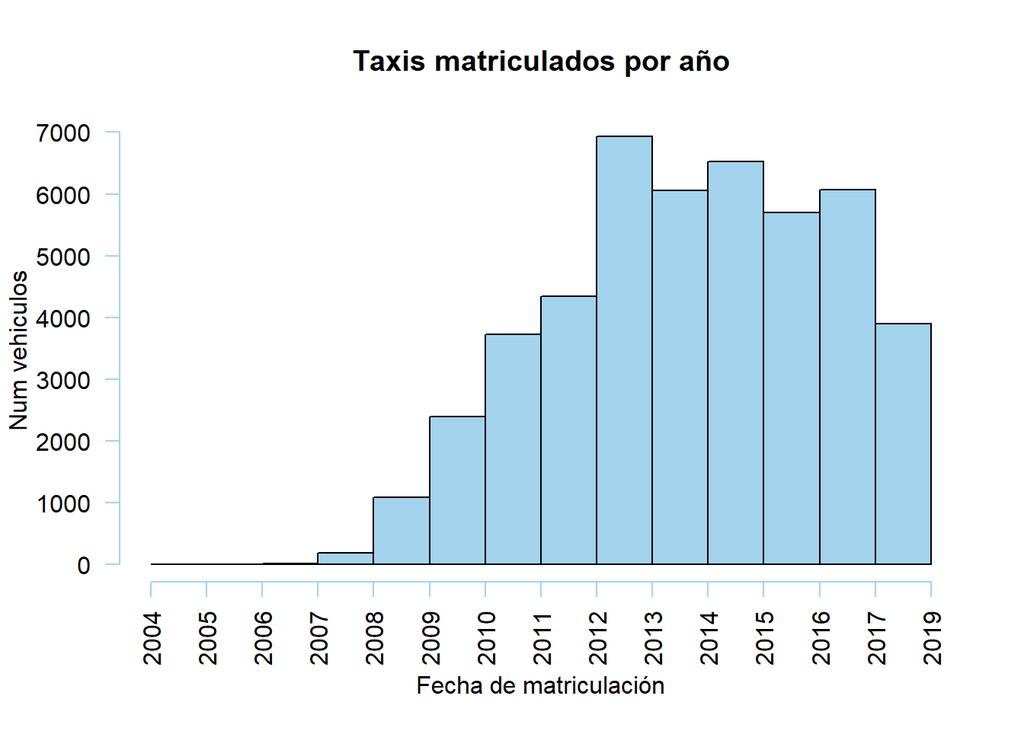

```r
hist(datos$fecha_matriculacion,
     breaks = "years",
     format = "%Y",
     freq = TRUE,
     las = 2,
     col = "lightskyblue2",
     xlab = "Fecha de matriculación",
     ylab = "Num vehiculos",
     main = "Taxis matriculados por año")
```

## Evolución del inicio de la actividad de taxis por año

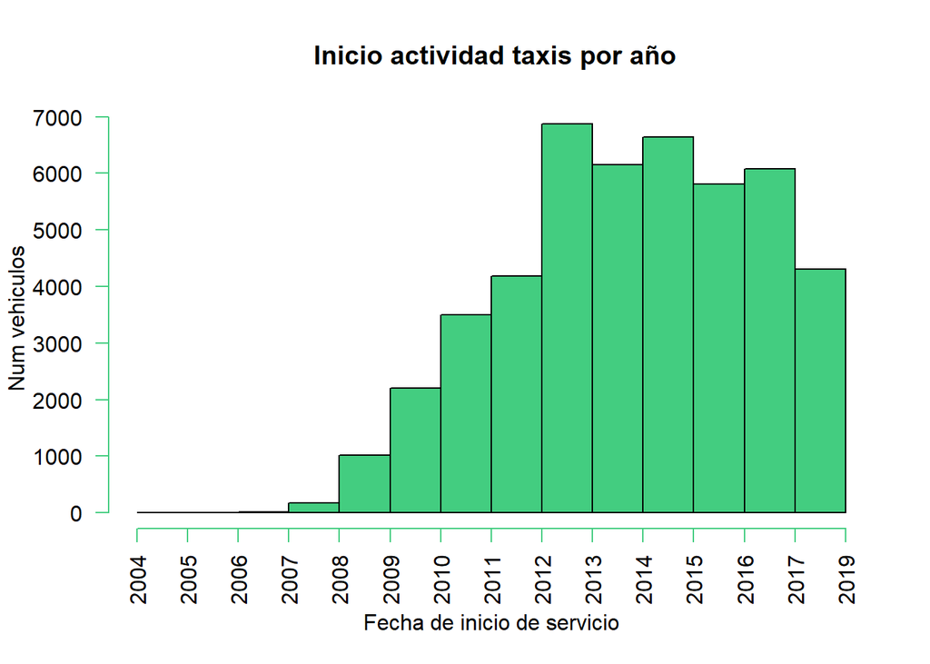

```r
hist(datos$fecha_inicio_prestacion,
     breaks = "years",
     format = "%Y",
     freq = TRUE,
     las = 2,
     col = "seagreen3",
     xlab = "Fecha de inicio de servicio",
     ylab = "Num vehiculos",
     main = " Inicio actividad taxis por año")
```

Podemos observar que no hay mucha variación entre el histograma anterior y este. Es decir, lo lógico es que los taxis sean matriculados e inicien su servicio en el mismo año.

Para comprobarlo, vemos la relación entre la fecha de matriculación y la fecha de inicio de la actividad de taxis. Observamos que hay una relación directa entre ambas, con algunos casos cuya fecha de inicio de actividad es superior a la fecha de matriculación

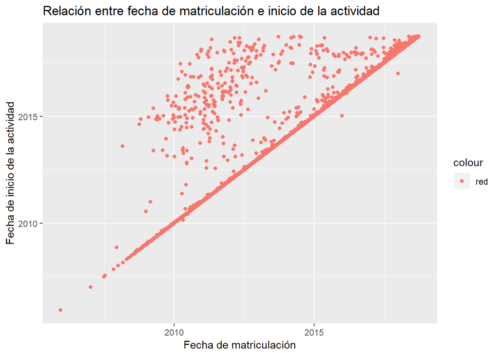

```r
library (ggplot2)
qplot(datos$fecha_matriculacion, datos$fecha_inicio_prestacion,
      xlab = "Fecha de matriculación",
      ylab = "Fecha de inicio de la actividad",
      col = "red",
      main = "Relación entre fecha de matriculación e inicio de la actividad"
)
```

## Relación entre potencia y cilindrada según clasificación medioambiental

Para evitar problemas con datos en blancos, los sustituimos por “0”

```r
datos$potencia[is.na(datos$potencia)] <- 0
```

No se puede asumir una relación directa entre los coches con nivel de contaminación 0, una vez que el número de casos que asume este valor es muy reducido y no se pueden sacar conclusiones.

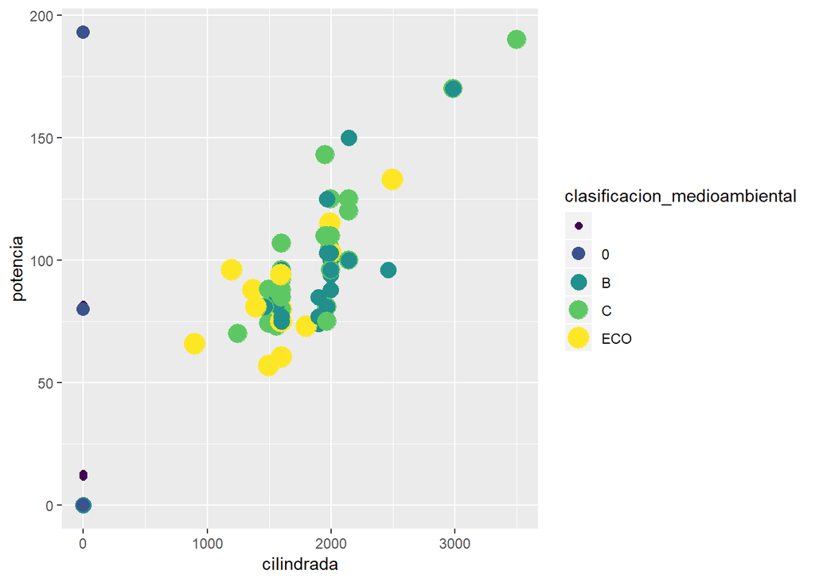

```r
ggplot(datos, aes(x = cilindrada, y =potencia, colour = clasificacion_medioambiental)) + geom_point(aes(size = clasificacion_medioambiental))
```